# Lecture 20: Correlation

Data Analysis for Psychology in R 1

Tom Booth

Click for slides

## Today

- Introduce Pearson correlation
  - Build from variance…
  - …to covariance…
  - …to correlation.

## Learning objectives

- Understand the basic features of correlation coefficients.
- Understand the relation between covariance and correlation.
- Understand how to calculate Pearson correlation.
- Know how to use R to calculate correlations.

## Purpose

- Correlations measure the degree of association between two variables.
  - If one goes up does the other go up (positive association)?
  - If one variable changes (varies) does the other change (vary) too.
  - If one goes up does the other go down (negative association)?
- The value ranges from -1 to 1.
  - Values close to |1| indicate stronger associations.
    - Values close to 0 indicate no association.

## Data Requirements

- There is a tight of correlation for almost all data types.

| X | Y | Correlation Type |
| --- | --- | --- |
| Continuous | Continuous | Pearson |
| Continuous | Categorical | Polyserial |
| Continuous | Binary | Biserial |
| Categorical | Categorical | Polychoric |
| Binary | Binary | Tetrachoric |
| Rank | Rank | Spearman |
| Nominal | Nominal | Chi-square |

## Scatterplots

- Typical visualization of correlations is through scatterplots.
- Scatterplots plot points at the (x,y) co-ordinates for two measured variables.
- We plot these points for each individual in our data set.
  - This produces the clouds of points.

## Simple Data

```r
data <- tibble(
  name = as_factor(c("John", "Peter","Robert","David","George","Matthew", "Bradley")),
  height = c(1.52,1.60,1.68,1.78,1.86,1.94,2.09),
  weight = c(54,49,50,67,70,110,98)
)
```

```
# A tibble: 6 x 3
  name    height weight
  <fct>    <dbl>  <dbl>
1 John      1.52     54
2 Peter     1.6      49
3 Robert    1.68     50
4 David     1.78     67
5 George    1.86     70
6 Matthew   1.94    110
```

## Scatterplot

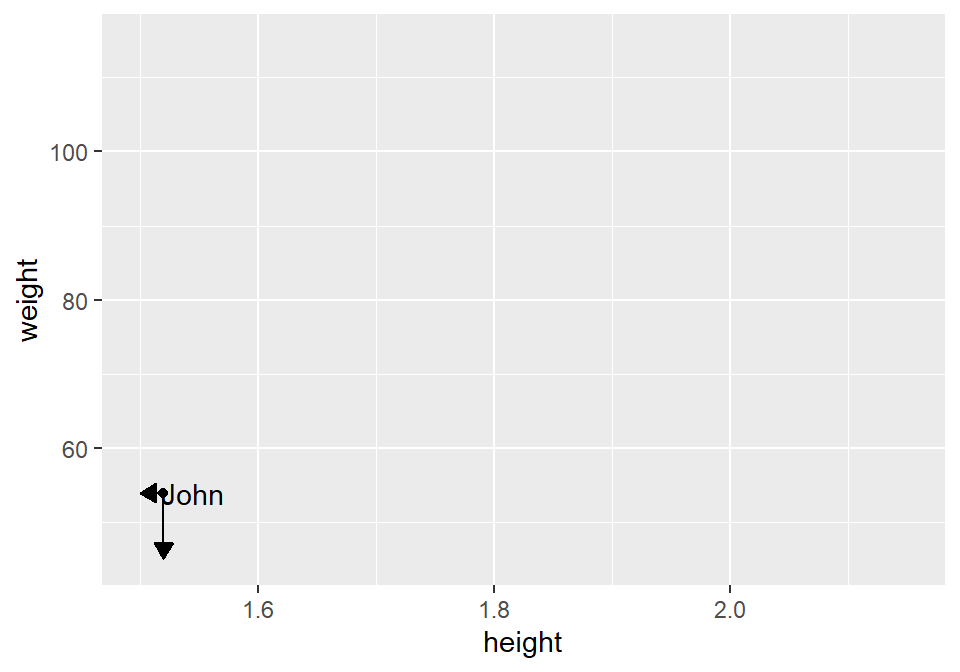

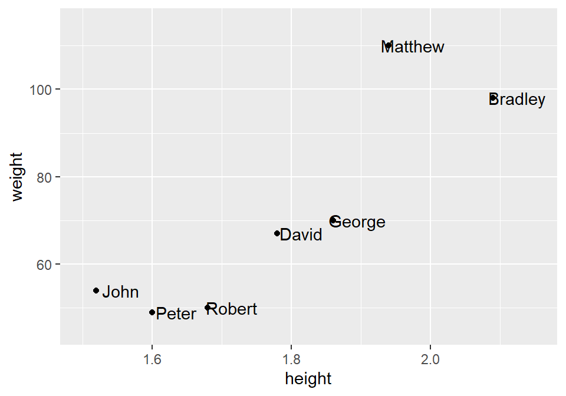

## Strength of correlation

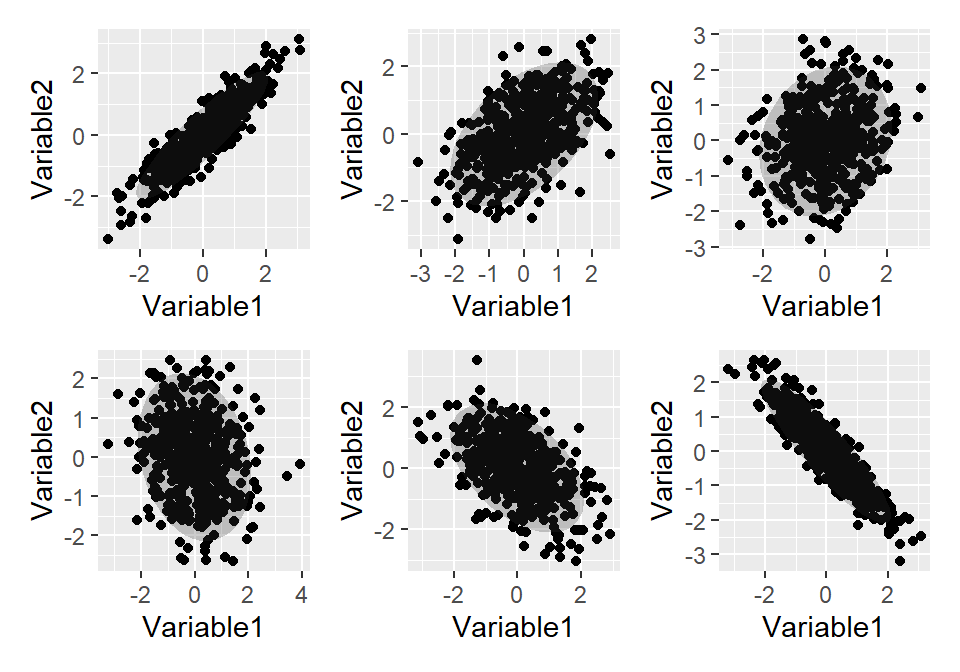

## Variance

$$Var_x = \frac{\sum_{i=1}^{N}{(x_i - \bar{x})}^2}{N-1}$$

- Variance is the mean squared deviation from the mean.

## Variance

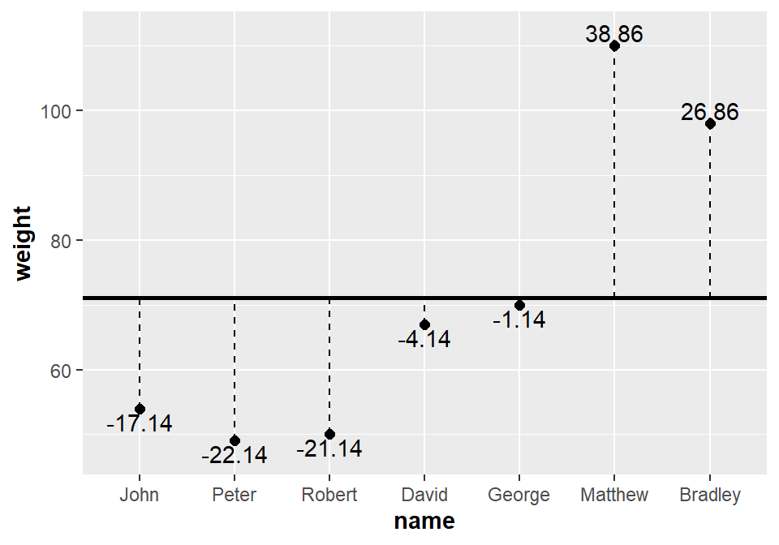

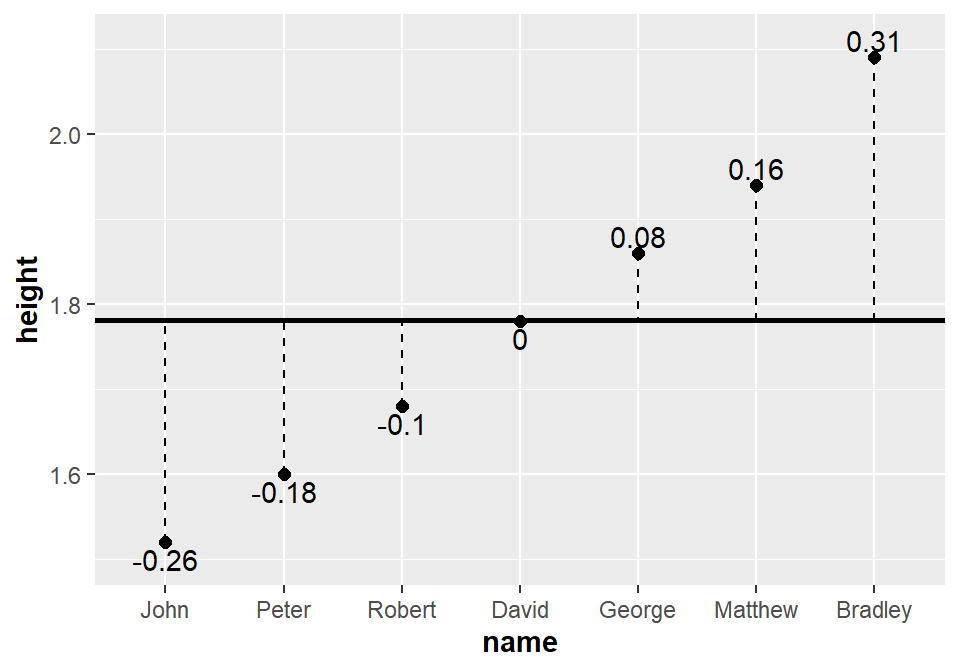

## Covariance

- So variance = deviation around the mean of a single variable.
- **Co**variance concerns variation in two variables.
- To think about the equation for covariance, suppose we re-write variance as follows. Instead of:

$$Var_x = \frac{\sum_{i=1}^{N}{(x_i - \bar{x})}^2}{N-1}$$

- we use

$$Cov_{xx} = \frac{\sum_{i=1}^{N}{(x_i - \bar{x})(x_i - \bar{x})}}{N-1}$$

$$Cov_{xy} = \frac{\sum_{i=1}^{N}{(x_i - \bar{x})(y_i - \bar{y})}}{N-1}$$

- So our covariance is identical to our variance, with the exception that our summed termed is the combined deviance from the respective means of both $x$ and $y$.
- For our data:

```r
round(cov(data$height, data$weight),4)
[1] 4.1681
```

## Scale & Covariance

- So what does a covariance of 4.1681 between height and weight mean?
  - I have no idea!
- Covariance is related to the scale of the variables we are analysing.
  - Makes sense right? variance was just the same.
- What about if we had measured height in centimetres not metres?

```r
round(cov(data$height*100, data$weight),2)
[1] 416.81
```

## Correlation

- How do we deal with problems of scale?
  - We standardize.
- And how do we standardize?
  - We divide by an estimate of the variability.
    - Here, the product of standard deviations of X and Y.
- The resulting statistic is the Pearson Product Moment Correlation ($r$)

$$r = \frac{Cov_{xy}}{SD_xSD_y}$$

- Or in full

$$r = \frac{\frac{\sum_{i=1}^{N}{(x_i - \bar{x})(y_i - \bar{y})}}{N-1}}{\sqrt{\frac{\sum_{i=1}^{N}{(x_i - \bar{x})}^2}{N-1}} \sqrt{\frac{\sum_{i=1}^{N}{(x_i - \bar{x})}^2}{N-1}}}$$

- In our data:

```r
cov(data$height, data$weight)/ (sd(data$height)*sd(data$weight))
[1] 0.8687186
```

- or we can use built in functions:

```r
cor(data$height, data$weight)
[1] 0.8687186
```

## Correlation = ES

- For some other tests we have discussed associated measures of effect size.
- Remember, an effect size is a standardized measures of the type relationship of interest.
  - So Cohen’s D is a standardize raw mean difference.
- Well our correlation **is** standardized
  - It is a standardized covariance.
  - Or a standardize measure of association

## Hypotheses

- For many people, correlations are descriptive statistics.
- As such, they do not require significance tests.
- But in other circumstances a correlation may be a test of interest, and we can formulate associated hypothesis tests.
- The association between two random variables = 0.
- As such, the null for a correlation is:

$$H_0: r = 0$$
- And the two-tailed alternative:

$$H_1: r \neq 0$$

- The sampling distribution of $r$ is approximately normal with large N, and is $t$ distributed when N is small.
  - Thus we assess the significance using the $t$-distribution with N-2 degrees of freedom.

## Hypothesis testing & significance

- The $t$-statistic for a given correlation is calculated as:

$$t = r \sqrt \frac{N-2}{1 - r^2}$$

- So for our data:

$$t = r \sqrt \frac{N-2}{1 - r^2} = 0.87 \sqrt \frac{5}{1 - 0.87^2} = 0.87\sqrt \frac{5}{0.2431} = 0.87*4.535 = 3.95$$

## Is our test significant?

- So the $t$ associated with our correlation is 3.95
  - Our degrees of freedom are N-2 = 7-2 = 5
  - We will use two-tailed $\alpha = .05$

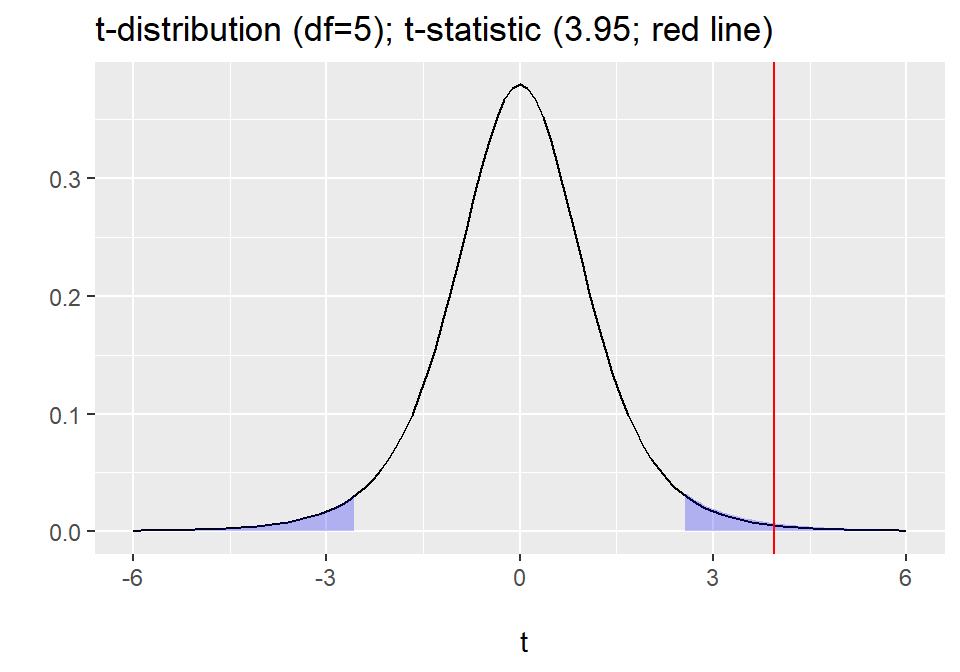

```
# A tibble: 1 x 2
  LowerCrit UpperCrit
      <dbl>     <dbl>
1     -2.57      2.57
```

## In R

```r
cor.test(data$height, data$weight)

    Pearson's product-moment correlation

data:  data$height and data$weight
t = 3.9218, df = 5, p-value = 0.01116
alternative hypothesis: true correlation is not equal to 0
95 percent confidence interval:
 0.3344679 0.9804020
sample estimates:
      cor
0.8687186
```

## Write up

- Write up is very simple for small number of variables.
- There was a strong positive correlation between height and weight ($r$(5) = .87, $p$<.05) in the current sample. As height increased, so did weight.
- Often we report lots of correlations and do so in a correlation matrix.

## Correlation matrices

- Values in diagonal are correlations with itself.
  - Always 1.00
  - Not informative
  - Can omit or replace with e.g. reliability
- Symmetric.
  - Above and below diagonal = same values.
  - Do not need both.
  - Could switch with p-values or leave empty

```r
pers_items <- bfi[,c(1:5)]
pers_cors <- hetcor(pers_items)
```

```r
pers_cors$correlations
           A1         A2         A3         A4         A5
A1  1.0000000 -0.3416242 -0.2682817 -0.1483927 -0.1826790
A2 -0.3416242  1.0000000  0.4867503  0.3352432  0.3877875
A3 -0.2682817  0.4867503  1.0000000  0.3621720  0.5051762
A4 -0.1483927  0.3352432  0.3621720  1.0000000  0.3067003
A5 -0.1826790  0.3877875  0.5051762  0.3067003  1.0000000
```

## Assumptions

- Variables must be interval or ratio (continuous)
  - No test: about design.
- Variables must be normally distributed.
  - Histograms, skew, QQ-Plots, Shapiro-Wilks.
- Homoscedasticity
- The relationship between the two variables must be linear.
  - Visualize: scatterplots.

## Anscombe Quartet

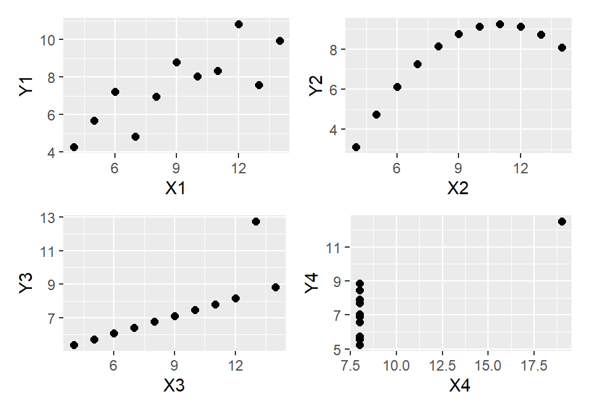

```r
round(cor(anscombe$x1, anscombe$y1),2)
[1] 0.82
round(cor(anscombe$x2, anscombe$y2),2)
[1] 0.82
round(cor(anscombe$x3, anscombe$y3),2)
[1] 0.82
round(cor(anscombe$x4, anscombe$y4),2)
[1] 0.82
```

## Correlation and causation

- You will talk more about this point in lab
  - And forever more when discussing statistical results.
- Typically we hope to be able to explain *why* things happen.
- Though correlation is a fundamental metric in statistics, it actually does not help us (on its own) with this.
- An association between two things does not mean it **causes** the other.
- Much more on this to come in lab and next year.

## Tasks for this week…

- Keep safe and healthy.